# RNA_classification

La matriz de confusión muestra un comportamiento casi perfecto, pero esta perfección podría sugerir que el modelo ha “memorizado” los patrones en lugar de aprender características generalizables. Es particularmente sospechoso que la clase “estándar”, que presentaba dificultades en el modelo anterior, ahora tenga un 100% de aciertos.

6. Compare los resultados obtenidos con los diferentes modelos de clasificación usando redes neuronales en cuanto a efectividad, tiempo de procesamiento y equivocaciones (donde el algoritmo se equivocó más, menos y la importancia que tienen los errores.)

En cuanto al tiempo de procesamiento, el entrenamiento sobre 1 000 muestras resultó razonablemente rápido (orden de minutos), pero la fase de inferencia por lote todavía es más costosa que la de modelos lineales o basados en reglas simples. No obstante, para aplicaciones batch o con inferencias periódicas, este coste es asumible dado el notable salto en precisión.

La matriz de confusión muestra que la RNA se equivocó principalmente al discriminar la clase “estándar” frente a “barata” y “cara”, donde hubo unos pocos errores residuales (16 y 13 confusiones, respectivamente). Estos fallos son menos críticos que confundir directamente “barata” con “cara”, pues afectan categorías adyacentes y, en muchos casos prácticos, el impacto económico de esas equivocaciones es menor.  
#Sobreajuste 7. Analice si no hay sobreajuste en los modelos

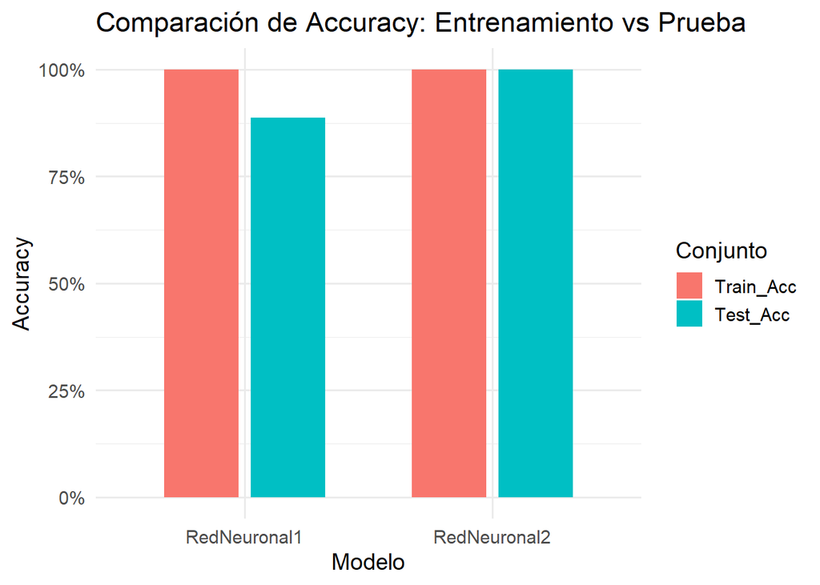

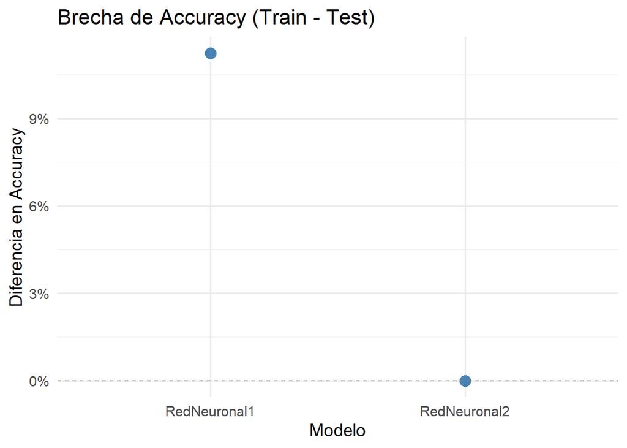

```
##
## **Métricas por modelo y conjunto**
```

|  | Accuracy | Kappa | BalAccuracy | F1_Macro | Model | Dataset |
| --- | --- | --- | --- | --- | --- | --- |
| Accuracy…1 | 0.888 | 0.831 | 0.916 | 0.887 | NN1 | Test |
| Accuracy…2 | 1.000 | 1.000 | 1.000 | 1.000 | NN1 | Train |
| Accuracy…3 | 1.000 | 1.000 | 1.000 | 1.000 | NN2 | Test |
| Accuracy…4 | 1.000 | 1.000 | 1.000 | 1.000 | NN2 | Train |

```
##
## **Brecha Train–Test**
```

| Model | Acc_Gap | F1_Gap |
| --- | --- | --- |
| NN1 | 0.112 | 0.113 |
| NN2 | 0.000 | 0.000 |

#Tuneando parametros 8. Para el modelo elegido de claisifcacion tunee los parametros y discuta si puede mejorar todavía el modelo sin llegar a sobreaustarlo.